# Tema 12 - Selección y regularización del modelo lineal

Universidad de Alicante, Curso 2021/22

## Métodos alternativos a Mínimos Cuadrados

\[ \small Y = \beta_0 + \beta_1 X_1 + \dots + \beta_k X_k + \varepsilon \]

- **Precisión**: mayor varianza cuando crece el número de parámetros/regresores relativo al de observaciones \(\Rightarrow\) no solución única de MCO con \(\small k>n\)
- **Interpretación**: un modelo con variables irrelevantes es más complejo y menos interpretable \(\Rightarrow\) selección de variables
1. **Selección** de variables: excluir variables irrelevantes y ajustar ese modelo reducido por mínimos cuadrados ordinarios
2. **Restricción** de los coeficientes estimados puede reducir la varianza, a costa de un aumento insignificante del sesgo (Regresión Regularizada/Penalizada)
3. **Reducción de la dimensionalidad**: usar \(\small M<k\) combinaciones lineales (proyecciones) y estimar por mínimos cuadrados (*PCR*, *PLS*)

## Métodos de selección de variables

- Selección del **mejor subconjunto**: estimar \(\small 2^k\) modelos posibles con cada combinación de regresores y elegir aquel con menor error \(\Rightarrow\) prohibitivo!
- Selección paso a paso **hacia adelante**: añadir un regresor cada vez, eligiendo aquel con menor error en cada paso \(\Rightarrow\) Factible (menor número de modelos)
  - No se garantiza encontrar el mejor subconjunto (ej., elimina pronto un regresor importante)
- Selección paso a paso **hacia atrás**: ídem (y además no factible si \(\small k>n\))
- **Selección mixta**: en cada paso se añaden variables de forma secuencial, pero también se eliminan algunas (p-valor alto)
- No tienen criterio riguroso ni llevan a la misma solución.
- Se pueden usar también en regresión logística

## Ajustes mediante penalización

- Sea \(\small n\) el número de observaciones, \(\small k\) el número de parámetros y \(\small \widehat{\sigma}^2\) un estimación de la varianza del error \(\small \varepsilon\)
- \(\small R^2-ajustado = 1- \frac{SCR/(n-k-1)}{SCT/(n-1)}\) o \(\small SCR/(n-k-1)\)
- \(\small C_k\) de Mallow: \(\small C_k = \frac{1}{n}\left( SCR + 2 k \widehat{\sigma}^2 \right)\)
- Criterio de Información de Akaike \(\small AIC = - 2 log L + 2 k\)
  - \(\small L\)=valor maximizado de la función de verosimilitud
- En modelos lineales con errores normales \(\small C_k = AIC\)
- Criterio de Información Bayesiano: \(\small BIC = \frac{1}{n}\left( SCR + log(n) k \widehat{\sigma}^2 \right)\)
  - \(\small n>7 \Rightarrow log(n)>2\), \(\small BIC\) penaliza más modelos con más parámetros

## ¿Cómo seleccionar modelos?

- Los métodos de ajuste ofrecen una estimación indirecta del error de prueba, en la muestra de entrenamiento mediante supuestos (erróneos?)
- ¿Ajustar o Validar?
  - Validación cruzada ofrece una estimación **más directa** pero es computacionalmente **más costosa**
  - Validación cruzada NO necesita estimar \(\small \widehat{\sigma}^2\) (difícil en algunos modelos)
- **Regla de parquedad paramétrica** o **de un error estándar**: dado un conjunto de modelos igualmente buenos, es mejor elegir el modelo más simple
  - seleccionar el modelo con menos variables que esté dentro de un error estándar del menor error de prueba estimado.

## Métodos de regularización

- En *MCO*: \(\small \min_{\beta} SCR={\sum_{i=1}^{n}\left(y-\widehat{y}\right)^2}\)
- En Regresión Penalizada o Regularizada, se añade una restricción que limite (reduzca) los coeficientes estimados \[\small \min_{\beta} SCR \text { sujeto a }R(\beta) \leq t\]
  - donde \(R(\cdot)\) es una función de penalización
  - NO se penaliza a la constante (media de \(\small Y\)), solo el impacto de \(\small X\)
- La restricción empeora el ajuste (sesgo), pero reduce la varianza \(\Rightarrow\) previene “overfitting”
- Permite ajustar un modelo que contenga **todos** los regresores

## Métodos de regularización (cont.)

- Reescribiendo el problema (Lagrangiano): \(\small \min_{\beta} SCR+\lambda R(\beta)\)
- \(\lambda \geq 0\) es un parámetro de ajuste (“tuning parameter”)

[output not shown]

## Penalización de contracción

\[\small \widehat{\beta}^R_{\lambda} = \arg \min_\beta SCR + \lambda \sum_{j=1}^{k}\beta_j^2 \]

\[\small \widehat{\beta}^L_{\lambda} = \arg \min_\beta SCR + \lambda \sum_{j=1}^{k}|\beta_j| \]

- Tratamos de ajustarnos a los datos minimizando SCR, PERO se recompensa a los coeficientes cercanos a cero
- \(\small \lambda\)= importancia de la penalización (cuanto se contraen los coeficientes)
  - \(\small \lambda \approx 0\), cercano a MCO
  - \(\small \lambda >> 0\), todos los coeficientes se van a cero
- Ventaja sobre la selección de regresores: SOLO necesitamos ajustar un modelo para cada valor de \(\small \lambda\)

## Advertencia: estandarizar los regresores

- En MCO los coeficientes estimados son equivariantes a la escala de los regresores.
  - Si multiplicamos \(\small X_j\) por una constante, \(\small c\), el coeficiente estimado se reescala por \(\small 1/c\) y el valor predicho \(\widehat{\beta_j}X_j\) sigue siendo el mismo.
  - \(SCR\) no cambia cuando se reescala un regresor
- En Regresión Regularizada, NO, porque la penalización sí cambia al reescalar \(\Rightarrow\) los coeficientes pueden cambiar drásticamente
- Se recomienda ajustar **después de estandarizar** los regresores: \[ \small \widetilde{x}_{ij} = \frac{x_{ij}}{\sqrt{ \frac{1}{n}\sum_{i=1}^n(x_{ij}-\bar{x}_j)^2}} \]

## Regularización y “Trade-off” sesgo-varianza

- ¿Por qué la regularización mejoraría el ajuste sobre MCO?
  - \(\small \lambda\) aumenta (menos parecido a MCO), la flexibilidad disminuye: más sesgo, menos varianza
  - \(\small \lambda\) disminuye, la flexibilidad aumenta: menos sesgo, más varianza
- Regularización funciona mejor cuando MCO tiene alta varianza: intercambia un poco más de sesgo por una gran reducción de la varianza
- “Ridge Regression” sigue incluyendo *todos* los regresores (puede complicar la interpretación con muchos: ningún coeficiente exactamente cero)
- LASSO (*least absolute shrinkage and selection operator*) realiza la selección de variables: también contrae los coeficientes estimados hacia cero, algunos **exactamente cero**

## “Ridge Regression” y LASSO

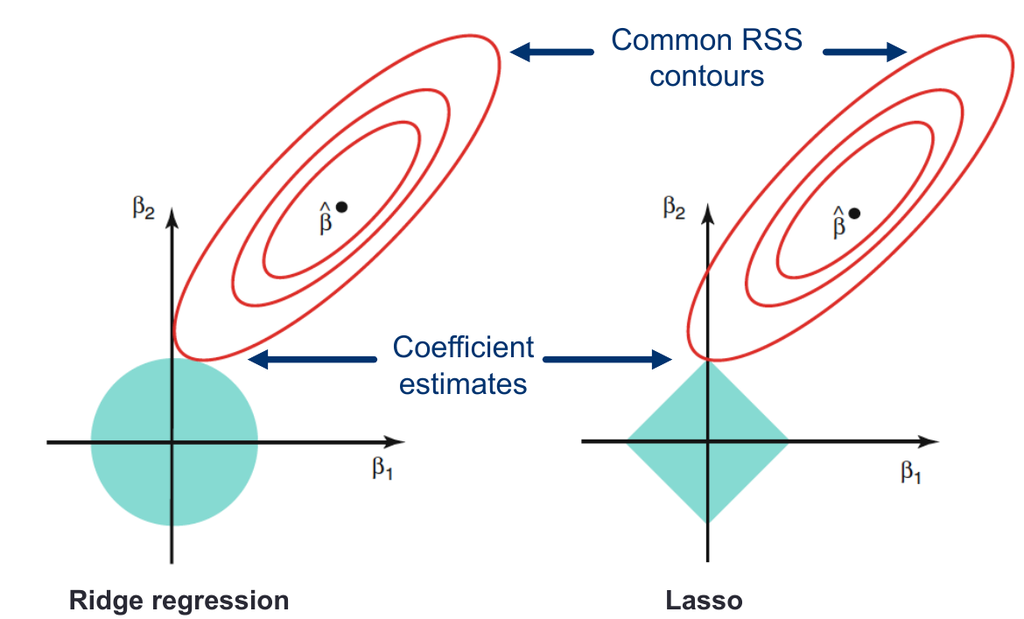

- “Ridge regression” domina con muchos regresores igualmente importantes
- LASSO con pocos regresores importantes y muchos inútiles

## Eligiendo el parámetro de ajuste

- Necesitamos un método para determinar qué modelo es el mejor: validación cruzada.
- Un algoritmo general para seleccionar un parámetro de ajuste:
  1. Elegir un rango de valores para \(\small \lambda\)
  2. Calcular el error mediante validación cruzada para cada valor de \(\small \lambda\)
  3. Seleccionar el valor con menor error
  4. Volver a ajustar el modelo usando todas las observaciones y el valor del parámetro de ajuste seleccionado.

## `glmnet` para regresión lineal

```r
library(mosaicData)
library(glmnet)

x <- model.matrix(volume ~ spring + summer + fall + weekday + poly(avgtemp, 6),
                  data = RailTrail)

fit.lmreg <- glmnet(x = x, y = RailTrail$volume, family="gaussian",
                    lambda=0.5, alpha=0.5)
coef(fit.lmreg)
```

- Elegimos el parámetero de regularización mediante validación cruzada

```r
set.seed(1)
cv.glmnet(x, RailTrail$volume) %>% plot()
```

## `glmnet` para regresión logística

```r
censo <- read_csv("data/census.csv") %>%
  mutate(income = as.integer(factor(income))-1)

x <- model.matrix(income ~ education + relationship + poly(age,2) +
                    workclass + occupation,
              family = "binomial", data = censo)

fit.glmreg <- glmnet(x = x, y = censo$income, lambda=0.001, alpha=1)
coef(fit.glmreg)

set.seed(1)  # validación cruzada para elegir parámetro de regularización
cv.glmnet(x, censo$income) %>% plot()
```